# 🎭 Facial Emotion Recognition using Deep Learning

## 7 Emotions Classes:

1. Angry
2. Disgust
3. Fear
4. Happy
5. Sad
6. Surprise
7. Neutral

# Step 1: Import Required Libraries

**What this does:**

- Imports TensorFlow/Keras for deep learning
- Imports visualization libraries (matplotlib, seaborn)
- Imports utilities for data processing and metrics

**ماذا يفعل هذا:**

- استيراد مكتبات التعلم العميق
- استيراد مكتبات الرسوم البيانية
- استيراد أدوات معالجة البيانات والمقاييس

```python
# Core Libraries
import os
import numpy as np
import matplotlib.pyplot as plt
import seaborn as sns
import json
from datetime import datetime

# TensorFlow and Keras
import tensorflow as tf
from tensorflow.keras.models import Model, load_model
from tensorflow.keras.layers import (
    Dense, Dropout, GlobalAveragePooling2D,
    BatchNormalization, Conv2D, MaxPooling2D, Flatten
)
from tensorflow.keras.preprocessing.image import ImageDataGenerator
from tensorflow.keras.optimizers import Adam
from tensorflow.keras.callbacks import (
    ModelCheckpoint, EarlyStopping, ReduceLROnPlateau, TensorBoard
)

# Metrics and Evaluation
from sklearn.metrics import (
    confusion_matrix, classification_report,
    accuracy_score, precision_recall_fscore_support
)

# Check TensorFlow version and GPU availability
print(f"TensorFlow version: {tf.__version__}")
print(f"GPU Available: {tf.config.list_physical_devices('GPU')}")
print(f"Num GPUs: {len(tf.config.list_physical_devices('GPU'))}")
```

```
TensorFlow version: 2.20.0
GPU Available: []
Num GPUs: 0
```

# Step 2: Configure Settings and Paths

**What this does:**

- Sets hyperparameters (batch size, image size, learning rate, etc.)
- Defines paths to dataset folders
- Creates output directories for saving models and results

**ماذا يفعل:**

- تحديد المعاملات الفائقة (حجم الدفعة، حجم الصورة، معدل التعلم، إلخ)
- تحديد مسارات مجلدات البيانات
- إنشاء مجلدات لحفظ النماذج والنتائج

```python
# ============================================
# CONFIGURATION SETTINGS
# ============================================

# Hyperparameters
IMG_SIZE = (224, 224)          # Image dimensions (required for MobileNetV2)
BATCH_SIZE = 32                # Number of images per batch (increase to 64 if you have GPU)
EPOCHS = 50                    # Maximum training epochs
LEARNING_RATE = 0.0001         # Initial learning rate
NUM_CLASSES = 7                # Number of emotion classes

# Dataset paths (CHANGE THESE TO YOUR ACTUAL PATHS)
TRAIN_DIR = "archive/train"    # Path to training images
VAL_DIR = "archive/val"        # Path to validation images
TEST_DIR = "archive/test"      # Path to test images

# Output directories
OUTPUT_DIR = "outputs"
MODEL_DIR = os.path.join(OUTPUT_DIR, "models")
RESULTS_DIR = os.path.join(OUTPUT_DIR, "results")
LOGS_DIR = os.path.join(OUTPUT_DIR, "logs")

# Create directories if they don't exist
os.makedirs(MODEL_DIR, exist_ok=True)
os.makedirs(RESULTS_DIR, exist_ok=True)
os.makedirs(LOGS_DIR, exist_ok=True)

# Model save path
BEST_MODEL_PATH = os.path.join(MODEL_DIR, "best_emotion_model.h5")
FINAL_MODEL_PATH = os.path.join(MODEL_DIR, "final_emotion_model.h5")

print("✅ Configuration completed!")
print(f"📁 Models will be saved to: {MODEL_DIR}")
print(f"📊 Results will be saved to: {RESULTS_DIR}")
```

```
✅ Configuration completed!
📁 Models will be saved to: outputs\models
📊 Results will be saved to: outputs\results
```

# Step 3: Data Preparation and Augmentation

**What this does:**

- Creates data generators for train/val/test sets
- **Training data**: Applies augmentation (rotation, shifts, flips) to prevent overfitting
- **Val/Test data**: Only normalizes (rescales to 0-1 range)
- Loads images in batches for efficient memory usage

**ماذا يفعل:**

- إنشاء مولدات البيانات لمجموعات التدريب/التحقق/الاختبار
- **بيانات التدريب**: تطبيق تعزيز البيانات (دوران، إزاحة، قلب) لمنع الإفراط في التجهيز
- **بيانات التحقق/الاختبار**: التطبيع فقط (إعادة القياس من 0 إلى 1)
- تحميل الصور على دفعات لاستخدام فعال للذاكرة

```python
# ============================================
# DATA AUGMENTATION CONFIGURATION
# ============================================

# Training data augmentation (to prevent overfitting)
train_datagen = ImageDataGenerator(
    rescale=1./255,                    # Normalize pixel values to [0, 1]
    rotation_range=20,                 # Random rotation up to 20 degrees
    width_shift_range=0.2,             # Random horizontal shift
    height_shift_range=0.2,            # Random vertical shift
    shear_range=0.2,                   # Random shear transformation
    zoom_range=0.2,                    # Random zoom
    brightness_range=[0.8, 1.2],       # Random brightness adjustment
    horizontal_flip=True,              # Random horizontal flip
    fill_mode='nearest'                # Fill strategy for new pixels
)

# Validation and Test data (only normalization, no augmentation)
val_datagen = ImageDataGenerator(rescale=1./255)
test_datagen = ImageDataGenerator(rescale=1./255)

print("✅ Data augmentation configured!")
```

```
✅ Data augmentation configured!
```

```python
# ============================================
# LOAD DATA FROM DIRECTORIES
# ============================================

# Load training data
train_generator = train_datagen.flow_from_directory(
    TRAIN_DIR,
    target_size=IMG_SIZE,
    color_mode="rgb",
    batch_size=BATCH_SIZE,
    class_mode="categorical",
    shuffle=True,
    seed=42
)

# Load validation data
val_generator = val_datagen.flow_from_directory(
    VAL_DIR,
    target_size=IMG_SIZE,
    color_mode="rgb",
    batch_size=BATCH_SIZE,
    class_mode="categorical",
    shuffle=False
)

# Load test data
test_generator = test_datagen.flow_from_directory(
    TEST_DIR,
    target_size=IMG_SIZE,
    color_mode="rgb",
    batch_size=BATCH_SIZE,
    class_mode="categorical",
    shuffle=False  # Important: Don't shuffle test data for evaluation
)

# Get emotion labels
emotion_labels = list(train_generator.class_indices.keys())
print(f"\n📋 Emotion Classes: {emotion_labels}")
print(f"\n📊 Dataset Statistics:")
print(f"   Training samples: {train_generator.samples}")
print(f"   Validation samples: {val_generator.samples}")
print(f"   Test samples: {test_generator.samples}")
print(f"   Batch size: {BATCH_SIZE}")
print(f"   Steps per epoch (train): {len(train_generator)}")
```

```
Found 28709 images belonging to 7 classes.
Found 3589 images belonging to 7 classes.
Found 3589 images belonging to 7 classes.

📋 Emotion Classes: ['Angry', 'Disgust', 'Fear', 'Happy', 'Neutral', 'Sad', 'Surprise']

📊 Dataset Statistics:
   Training samples: 28709
   Validation samples: 3589
   Test samples: 3589
   Batch size: 32
   Steps per epoch (train): 898
```

# Step 4: Visualize Sample Images

**What this does:**

**ماذا يفعل:**

```
📸 Sample Training Images:
```

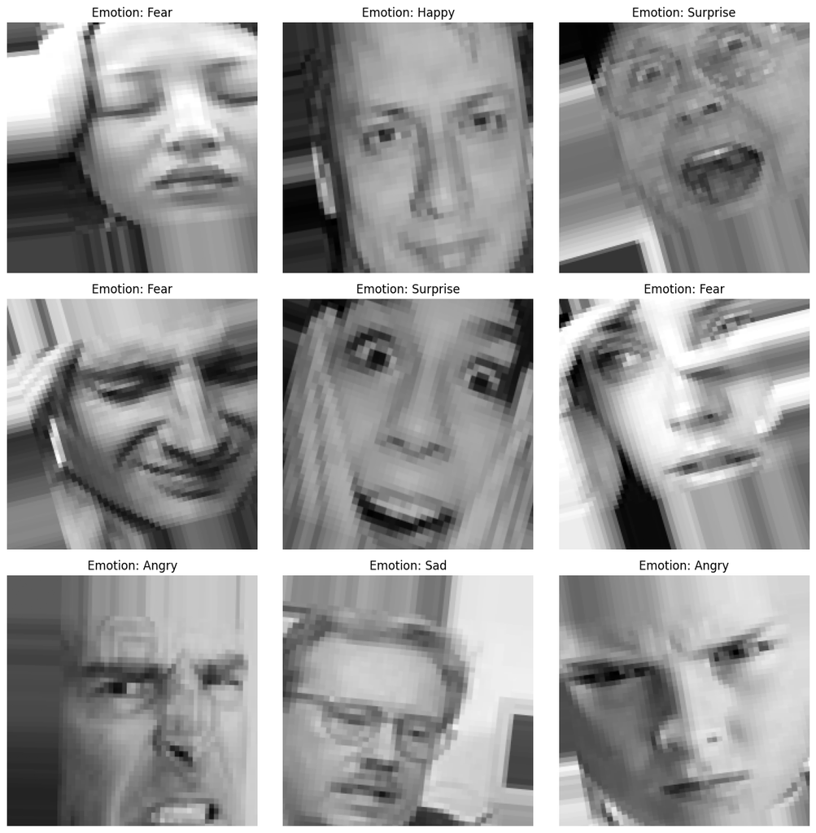

```python
# ============================================
# VISUALIZE SAMPLE IMAGES
# ============================================

def plot_sample_images(generator, num_images=9):
    """
    Display sample images from the dataset
    """
    images, labels = next(generator)

    plt.figure(figsize=(12, 12))
    for i in range(min(num_images, len(images))):
        plt.subplot(3, 3, i + 1)
        plt.imshow(images[i])
        emotion_idx = np.argmax(labels[i])
        plt.title(f"Emotion: {emotion_labels[emotion_idx]}")
        plt.axis('off')

    plt.tight_layout()
    plt.savefig(os.path.join(RESULTS_DIR, 'sample_images.png'), dpi=150, bbox_inches='tight')
    plt.show()

# Display sample training images
print("📸 Sample Training Images:")
plot_sample_images(train_generator)
```

```python
# this part to continue training the model (continue the epoch ) from the epoch which we stopped last time on the modle :
# run 1 to 4 only , then run this , don't rebuild the model from scratch (skip 5 to 8 steps)
# so you can after this go to step 9 to the last one
# ============================================
# RESUME TRAINING FROM CHECKPOINT
# ============================================

from tensorflow.keras.models import load_model
from tensorflow.keras.optimizers import Adam
from tensorflow.keras.callbacks import ModelCheckpoint, EarlyStopping, ReduceLROnPlateau, TensorBoard

print("="*60)
print("RESUMING TRAINING FROM SAVED CHECKPOINT")
print("="*60)

# Load the saved model
print("\n📂 Loading saved model...")
model = load_model(BEST_MODEL_PATH)
print(f"✅ Model loaded from: {BEST_MODEL_PATH}")

# Check current performance
print("\n📊 Current model performance:")
val_loss, val_acc = model.evaluate(val_generator, verbose=0)
print(f"   Validation accuracy: {val_acc:.4f} ({val_acc*100:.2f}%)")
print(f"   Validation loss: {val_loss:.4f}")

# Recompile the model
model.compile(
    optimizer=Adam(learning_rate=LEARNING_RATE),
    loss="categorical_crossentropy",
    metrics=["accuracy"]
)
print("✅ Model recompiled")

# Setup callbacks (same as before)
checkpoint = ModelCheckpoint(
    BEST_MODEL_PATH,
    monitor="val_loss",
    save_best_only=True,
    mode="min",
    verbose=1
)

early_stop = EarlyStopping(
    monitor="val_loss",
    patience=10,
    restore_best_weights=True,
    verbose=1
)

reduce_lr = ReduceLROnPlateau(
    monitor="val_loss",
    factor=0.5,
    patience=5,
    min_lr=1e-7,
    verbose=1
)

tensorboard = TensorBoard(
    log_dir=LOGS_DIR,
    histogram_freq=1
)

callbacks = [checkpoint, early_stop, reduce_lr, tensorboard]

# Resume training
initial_epoch = 31  # ⚠️ UPDATE THIS: The epoch where you stopped
total_epochs = 50

print(f"\n🚀 Resuming training...")
print(f"   Starting from epoch: {initial_epoch}")
print(f"   Training until epoch: {total_epochs}")
print(f"   Remaining epochs: {total_epochs - initial_epoch}")
print("="*60 + "\n")

# Continue training from where you left off
history = model.fit(
    train_generator,
    initial_epoch=initial_epoch,
    epochs=total_epochs,
    validation_data=val_generator,
    callbacks=callbacks,
    verbose=1
)

print("\n✅ Training completed!")
print(f"💾 Best model saved to: {BEST_MODEL_PATH}")
```

```
============================================================
RESUMING TRAINING FROM SAVED CHECKPOINT
============================================================

📂 Loading saved model...
```

```
WARNING:absl:Compiled the loaded model, but the compiled metrics have yet to be built. `model.compile_metrics` will be empty until you train or evaluate the model.
```

[output not shown]

[output not shown]

[output not shown]

[output not shown]

```
Epoch 13: finished saving model to outputs\models\best_emotion_model.h5
898/898 ━━━━━━━━━━━━━━━━━━━━ 570s 635ms/step - accuracy: 0.4080 - loss: 1.5288 - val_accuracy: 0.4533 - val_loss: 1.4341 - learning_rate: 1.0000e-04
898/898 ━━━━━━━━━━━━━━━━━━━━ 0s 576ms/step - accuracy: 0.4130 - loss: 1.5235
Epoch 14: val_loss did not improve from 1.43414
898/898 ━━━━━━━━━━━━━━━━━━━━ 561s 625ms/step - accuracy: 0.4137 - loss: 1.5188 - val_accuracy: 0.4489 - val_loss: 1.4344 - learning_rate: 1.0000e-04
898/898 ━━━━━━━━━━━━━━━━━━━━ 0s 559ms/step - accuracy: 0.4165 - loss: 1.5141
Epoch 15: val_loss did not improve from 1.43414
898/898 ━━━━━━━━━━━━━━━━━━━━ 547s 609ms/step - accuracy: 0.4143 - loss: 1.5108 - val_accuracy: 0.4497 - val_loss: 1.4346 - learning_rate: 1.0000e-04
898/898 ━━━━━━━━━━━━━━━━━━━━ 0s 730ms/step - accuracy: 0.4150 - loss: 1.5091
Epoch 16: val_loss improved from 1.43414 to 1.42207, saving model to outputs\models\best_emotion_model.h5
```

[output not shown]

```
Epoch 16: finished saving model to outputs\models\best_emotion_model.h5
898/898 ━━━━━━━━━━━━━━━━━━━━ 706s 787ms/step - accuracy: 0.4157 - loss: 1.5043 - val_accuracy: 0.4564 - val_loss: 1.4221 - learning_rate: 1.0000e-04
898/898 ━━━━━━━━━━━━━━━━━━━━ 0s 1s/step - accuracy: 0.4206 - loss: 1.4965
Epoch 17: val_loss improved from 1.42207 to 1.41945, saving model to outputs\models\best_emotion_model.h5
```

[output not shown]

```
Epoch 17: finished saving model to outputs\models\best_emotion_model.h5
898/898 ━━━━━━━━━━━━━━━━━━━━ 1368s 2s/step - accuracy: 0.4217 - loss: 1.4962 - val_accuracy: 0.4553 - val_loss: 1.4194 - learning_rate: 1.0000e-04
898/898 ━━━━━━━━━━━━━━━━━━━━ 0s 1s/step - accuracy: 0.4256 - loss: 1.5001
Epoch 18: val_loss did not improve from 1.41945
898/898 ━━━━━━━━━━━━━━━━━━━━ 1245s 1s/step - accuracy: 0.4252 - loss: 1.4949 - val_accuracy: 0.4497 - val_loss: 1.4283 - learning_rate: 1.0000e-04
898/898 ━━━━━━━━━━━━━━━━━━━━ 0s 594ms/step - accuracy: 0.4254 - loss: 1.4855
Epoch 19: val_loss improved from 1.41945 to 1.41890, saving model to outputs\models\best_emotion_model.h5
```

[output not shown]

```
Epoch 19: finished saving model to outputs\models\best_emotion_model.h5
898/898 ━━━━━━━━━━━━━━━━━━━━ 578s 644ms/step - accuracy: 0.4249 - loss: 1.4914 - val_accuracy: 0.4533 - val_loss: 1.4189 - learning_rate: 1.0000e-04
898/898 ━━━━━━━━━━━━━━━━━━━━ 0s 591ms/step - accuracy: 0.4223 - loss: 1.4906
Epoch 20: val_loss did not improve from 1.41890
898/898 ━━━━━━━━━━━━━━━━━━━━ 574s 639ms/step - accuracy: 0.4254 - loss: 1.4868 - val_accuracy: 0.4544 - val_loss: 1.4196 - learning_rate: 1.0000e-04
898/898 ━━━━━━━━━━━━━━━━━━━━ 0s 600ms/step - accuracy: 0.4303 - loss: 1.4756
Epoch 21: val_loss improved from 1.41890 to 1.40711, saving model to outputs\models\best_emotion_model.h5
```

[output not shown]

```
Epoch 21: finished saving model to outputs\models\best_emotion_model.h5
898/898 ━━━━━━━━━━━━━━━━━━━━ 584s 650ms/step - accuracy: 0.4248 - loss: 1.4848 - val_accuracy: 0.4617 - val_loss: 1.4071 - learning_rate: 1.0000e-04
898/898 ━━━━━━━━━━━━━━━━━━━━ 0s 584ms/step - accuracy: 0.4320 - loss: 1.4756
Epoch 22: val_loss did not improve from 1.40711
898/898 ━━━━━━━━━━━━━━━━━━━━ 570s 634ms/step - accuracy: 0.4311 - loss: 1.4791 - val_accuracy: 0.4544 - val_loss: 1.4183 - learning_rate: 1.0000e-04
898/898 ━━━━━━━━━━━━━━━━━━━━ 0s 610ms/step - accuracy: 0.4359 - loss: 1.4724
Epoch 23: val_loss did not improve from 1.40711
898/898 ━━━━━━━━━━━━━━━━━━━━ 592s 659ms/step - accuracy: 0.4333 - loss: 1.4761 - val_accuracy: 0.4575 - val_loss: 1.4106 - learning_rate: 1.0000e-04
898/898 ━━━━━━━━━━━━━━━━━━━━ 0s 570ms/step - accuracy: 0.4352 - loss: 1.4691
Epoch 24: val_loss did not improve from 1.40711
898/898 ━━━━━━━━━━━━━━━━━━━━ 557s 620ms/step - accuracy: 0.4356 - loss: 1.4664 - val_accuracy: 0.4408 - val_loss: 1.4434 - learning_rate: 1.0000e-04
898/898 ━━━━━━━━━━━━━━━━━━━━ 0s 581ms/step - accuracy: 0.4332 - loss: 1.4690
Epoch 25: val_loss did not improve from 1.40711
898/898 ━━━━━━━━━━━━━━━━━━━━ 564s 628ms/step - accuracy: 0.4359 - loss: 1.4638 - val_accuracy: 0.4544 - val_loss: 1.4160 - learning_rate: 1.0000e-04
898/898 ━━━━━━━━━━━━━━━━━━━━ 0s 583ms/step - accuracy: 0.4348 - loss: 1.4626
Epoch 26: val_loss improved from 1.40711 to 1.40708, saving model to outputs\models\best_emotion_model.h5
```

[output not shown]

```
Epoch 26: finished saving model to outputs\models\best_emotion_model.h5

Epoch 26: ReduceLROnPlateau reducing learning rate to 4.999999873689376e-05.
898/898 ━━━━━━━━━━━━━━━━━━━━ 566s 630ms/step - accuracy: 0.4333 - loss: 1.4658 - val_accuracy: 0.4611 - val_loss: 1.4071 - learning_rate: 1.0000e-04
898/898 ━━━━━━━━━━━━━━━━━━━━ 0s 549ms/step - accuracy: 0.4332 - loss: 1.4574
Epoch 27: val_loss improved from 1.40708 to 1.40542, saving model to outputs\models\best_emotion_model.h5
```

[output not shown]

```
Epoch 27: finished saving model to outputs\models\best_emotion_model.h5
898/898 ━━━━━━━━━━━━━━━━━━━━ 537s 597ms/step - accuracy: 0.4357 - loss: 1.4577 - val_accuracy: 0.4564 - val_loss: 1.4054 - learning_rate: 5.0000e-05
898/898 ━━━━━━━━━━━━━━━━━━━━ 0s 602ms/step - accuracy: 0.4379 - loss: 1.4609
Epoch 28: val_loss improved from 1.40542 to 1.40283, saving model to outputs\models\best_emotion_model.h5
```

[output not shown]

```
Epoch 28: finished saving model to outputs\models\best_emotion_model.h5
898/898 ━━━━━━━━━━━━━━━━━━━━ 590s 657ms/step - accuracy: 0.4379 - loss: 1.4553 - val_accuracy: 0.4622 - val_loss: 1.4028 - learning_rate: 5.0000e-05
898/898 ━━━━━━━━━━━━━━━━━━━━ 0s 758ms/step - accuracy: 0.4374 - loss: 1.4565
Epoch 29: val_loss improved from 1.40283 to 1.38976, saving model to outputs\models\best_emotion_model.h5
```

[output not shown]

```
Epoch 29: finished saving model to outputs\models\best_emotion_model.h5
898/898 ━━━━━━━━━━━━━━━━━━━━ 731s 814ms/step - accuracy: 0.4401 - loss: 1.4570 - val_accuracy: 0.4653 - val_loss: 1.3898 - learning_rate: 5.0000e-05
898/898 ━━━━━━━━━━━━━━━━━━━━ 0s 845ms/step - accuracy: 0.4448 - loss: 1.4414
Epoch 30: val_loss did not improve from 1.38976
898/898 ━━━━━━━━━━━━━━━━━━━━ 808s 900ms/step - accuracy: 0.4422 - loss: 1.4493 - val_accuracy: 0.4670 - val_loss: 1.3921 - learning_rate: 5.0000e-05
169/898 ━━━━━━━━━━━━━━━━━━━━ 9:17 765ms/step - accuracy: 0.4531 - loss: 1.4469
```

[output not shown]

[output cut: 75 more lines]

[output not shown]

# Step 5: Build the Model (Transfer Learning with MobileNetV2)

**What this does:**

- Uses **MobileNetV2** pretrained on ImageNet as the base (frozen)
- Adds custom classification layers on top:
  - GlobalAveragePooling2D (reduces feature dimensions)
  - Dense layer (512 neurons) with ReLU activation
  - BatchNormalization (stabilizes training)
  - Dropout (50% - prevents overfitting)
  - Output layer (7 neurons with Softmax for emotion classification)

**ماذا يفعل:**

- يستخدم **MobileNetV2** المدرب مسبقاً على ImageNet كقاعدة (مجمدة)
- يضيف طبقات تصنيف مخصصة:
  - GlobalAveragePooling2D (تقليل أبعاد الميزات)
  - طبقة Dense (512 خلية عصبية) مع تفعيل ReLU
  - BatchNormalization (استقرار التدريب)
  - Dropout (50% - منع الإفراط في التجهيز)
  - طبقة الإخراج (7 خلايا مع Softmax لتصنيف المشاعر)

```python
# ============================================
# BUILD MODEL USING TRANSFER LEARNING
# ============================================

def build_model():
    """
    Build emotion recognition model using MobileNetV2 transfer learning

    Architecture:
    1. MobileNetV2 base (pretrained, frozen)
    2. GlobalAveragePooling2D
    3. Dense(512) + BatchNorm + Dropout
    4. Dense(256) + BatchNorm + Dropout
    5. Output Dense(7) with Softmax
    """

    # Load pretrained MobileNetV2 (without top classification layer)
    base_model = tf.keras.applications.MobileNetV2(
        input_shape=(IMG_SIZE[0], IMG_SIZE[1], 3),
        include_top=False,
        weights="imagenet"
    )

    # Freeze base model layers (we'll only train the custom head)
    base_model.trainable = False

    # Build custom classification head
    x = base_model.output
    x = GlobalAveragePooling2D()(x)                      # Reduce spatial dimensions

    # First dense block
    x = Dense(512, activation="relu")(x)
    x = BatchNormalization()(x)
    x = Dropout(0.5)(x)

    # Second dense block
    x = Dense(256, activation="relu")(x)
    x = BatchNormalization()(x)
    x = Dropout(0.4)(x)

    # Output layer (7 emotions with softmax)
    output = Dense(NUM_CLASSES, activation="softmax")(x)

    # Create model
    model = Model(inputs=base_model.input, outputs=output)

    return model, base_model

# Build the model
model, base_model = build_model()

# Display model summary
print("\n📊 Model Architecture:")
model.summary()

# Count parameters
total_params = model.count_params()
trainable_params = sum([tf.keras.backend.count_params(w) for w in model.trainable_weights])
non_trainable_params = total_params - trainable_params

print(f"\n📈 Model Parameters:")
print(f"   Total parameters: {total_params:,}")
print(f"   Trainable parameters: {trainable_params:,}")
print(f"   Non-trainable parameters: {non_trainable_params:,}")
```

```
📊 Model Architecture:
```

```
Model: "functional"
```

```
┏━━━━━━━━━━━━━━━━━━━━━┳━━━━━━━━━━━━━━━━━━━┳━━━━━━━━━━━━┳━━━━━━━━━━━━━━━━━━━┓
┃ Layer (type)        ┃ Output Shape      ┃    Param # ┃ Connected to      ┃
┡━━━━━━━━━━━━━━━━━━━━━╇━━━━━━━━━━━━━━━━━━━╇━━━━━━━━━━━━╇━━━━━━━━━━━━━━━━━━━┩
│ input_layer         │ (None, 224, 224,  │          0 │ -                 │
│ (InputLayer)        │ 3)                │            │                   │
├─────────────────────┼───────────────────┼────────────┼───────────────────┤
│ Conv1 (Conv2D)      │ (None, 112, 112,  │        864 │ input_layer[0][0] │
│                     │ 32)               │            │                   │
├─────────────────────┼───────────────────┼────────────┼───────────────────┤
│ bn_Conv1            │ (None, 112, 112,  │        128 │ Conv1[0][0]       │
│ (BatchNormalizatio… │ 32)               │            │                   │
├─────────────────────┼───────────────────┼────────────┼───────────────────┤
│ Conv1_relu (ReLU)   │ (None, 112, 112,  │          0 │ bn_Conv1[0][0]    │
│                     │ 32)               │            │                   │
├─────────────────────┼───────────────────┼────────────┼───────────────────┤
│ expanded_conv_dept… │ (None, 112, 112,  │        288 │ Conv1_relu[0][0]  │
│ (DepthwiseConv2D)   │ 32)               │            │                   │
├─────────────────────┼───────────────────┼────────────┼───────────────────┤
│ expanded_conv_dept… │ (None, 112, 112,  │        128 │ expanded_conv_de… │
│ (BatchNormalizatio… │ 32)               │            │                   │
├─────────────────────┼───────────────────┼────────────┼───────────────────┤
│ expanded_conv_dept… │ (None, 112, 112,  │          0 │ expanded_conv_de… │
│ (ReLU)              │ 32)               │            │                   │
├─────────────────────┼───────────────────┼────────────┼───────────────────┤
│ expanded_conv_proj… │ (None, 112, 112,  │        512 │ expanded_conv_de… │
│ (Conv2D)            │ 16)               │            │                   │
├─────────────────────┼───────────────────┼────────────┼───────────────────┤
│ expanded_conv_proj… │ (None, 112, 112,  │         64 │ expanded_conv_pr… │
│ (BatchNormalizatio… │ 16)               │            │                   │
├─────────────────────┼───────────────────┼────────────┼───────────────────┤
│ block_1_expand      │ (None, 112, 112,  │      1,536 │ expanded_conv_pr… │
│ (Conv2D)            │ 96)               │            │                   │
├─────────────────────┼───────────────────┼────────────┼───────────────────┤
│ block_1_expand_BN   │ (None, 112, 112,  │        384 │ block_1_expand[0… │
│ (BatchNormalizatio… │ 96)               │            │                   │
├─────────────────────┼───────────────────┼────────────┼───────────────────┤
│ block_1_expand_relu │ (None, 112, 112,  │          0 │ block_1_expand_B… │
│ (ReLU)              │ 96)               │            │                   │
├─────────────────────┼───────────────────┼────────────┼───────────────────┤
│ block_1_pad         │ (None, 113, 113,  │          0 │ block_1_expand_r… │
```

[output cut: 429 more lines]

```
├─────────────────────┼───────────────────┼────────────┼───────────────────┤
│ batch_normalization │ (None, 512)       │      2,048 │ dense[0][0]       │
│ (BatchNormalizatio… │                   │            │                   │
├─────────────────────┼───────────────────┼────────────┼───────────────────┤
│ dropout (Dropout)   │ (None, 512)       │          0 │ batch_normalizat… │
├─────────────────────┼───────────────────┼────────────┼───────────────────┤
│ dense_1 (Dense)     │ (None, 256)       │    131,328 │ dropout[0][0]     │
├─────────────────────┼───────────────────┼────────────┼───────────────────┤
│ batch_normalizatio… │ (None, 256)       │      1,024 │ dense_1[0][0]     │
│ (BatchNormalizatio… │                   │            │                   │
├─────────────────────┼───────────────────┼────────────┼───────────────────┤
│ dropout_1 (Dropout) │ (None, 256)       │          0 │ batch_normalizat… │
├─────────────────────┼───────────────────┼────────────┼───────────────────┤
│ dense_2 (Dense)     │ (None, 7)         │      1,799 │ dropout_1[0][0]   │
└─────────────────────┴───────────────────┴────────────┴───────────────────┘
```

```
 Total params: 3,050,055 (11.64 MB)
```

```
 Trainable params: 790,535 (3.02 MB)
```

```
 Non-trainable params: 2,259,520 (8.62 MB)
```

```
📈 Model Parameters:
   Total parameters: 3,050,055
   Trainable parameters: 790,535
   Non-trainable parameters: 2,259,520
```

# Step 6: Compile the Model

**What this does:**

- Configures the model for training
- **Optimizer**: Adam (adaptive learning rate)
- **Loss function**: Categorical crossentropy (for multi-class classification)
- **Metrics**: Accuracy (to track performance)

**ماذا يفعل:**

- تهيئة النموذج للتدريب
- **المحسن**: Adam (معدل تعلم تكيفي)
- **دالة الخسارة**: Categorical crossentropy (للتصنيف متعدد الفئات)
- **المقاييس**: الدقة (لتتبع الأداء)

```python
# ============================================
# COMPILE MODEL
# ============================================

model.compile(
    optimizer=Adam(learning_rate=LEARNING_RATE),
    loss="categorical_crossentropy",
    metrics=["accuracy"]
)

print("✅ Model compiled successfully!")
print(f"   Optimizer: Adam (lr={LEARNING_RATE})")
print(f"   Loss: categorical_crossentropy")
print(f"   Metrics: accuracy")
```

```
✅ Model compiled successfully!
   Optimizer: Adam (lr=0.0001)
   Loss: categorical_crossentropy
   Metrics: accuracy
```

# Step 7: Setup Training Callbacks

**What this does:**

- **ModelCheckpoint**: Saves best model based on validation loss
- **EarlyStopping**: Stops training if no improvement for 10 epochs
- **ReduceLROnPlateau**: Reduces learning rate when stuck
- **TensorBoard**: Logs training metrics for visualization

**ماذا يفعل:**

- **ModelCheckpoint**: حفظ أفضل نموذج بناءً على خسارة التحقق
- **EarlyStopping**: إيقاف التدريب إذا لم يكن هناك تحسن لمدة 10 epochs
- **ReduceLROnPlateau**: تقليل معدل التعلم عند التوقف
- **TensorBoard**: تسجيل مقاييس التدريب للتصور

```python
# ============================================
# SETUP CALLBACKS FOR TRAINING
# ============================================

# 1. ModelCheckpoint - saves best model
checkpoint = ModelCheckpoint(
    BEST_MODEL_PATH,
    monitor="val_loss",
    save_best_only=True,
    mode="min",
    verbose=1
)

# 2. EarlyStopping - stops if no improvement
early_stop = EarlyStopping(
    monitor="val_loss",
    patience=10,
    restore_best_weights=True,
    verbose=1
)

# 3. ReduceLROnPlateau - reduces learning rate when stuck
reduce_lr = ReduceLROnPlateau(
    monitor="val_loss",
    factor=0.5,
    patience=5,
    min_lr=1e-7,
    verbose=1
)

# 4. TensorBoard - for visualization
tensorboard = TensorBoard(
    log_dir=LOGS_DIR,
    histogram_freq=1
)

# Combine all callbacks
callbacks = [checkpoint, early_stop, reduce_lr, tensorboard]

print("✅ Callbacks configured:")
print("   - ModelCheckpoint (saves best model)")
print("   - EarlyStopping (patience=10)")
print("   - ReduceLROnPlateau (factor=0.5, patience=5)")
print("   - TensorBoard (logging enabled)")
```

```
✅ Callbacks configured:
   - ModelCheckpoint (saves best model)
   - EarlyStopping (patience=10)
   - ReduceLROnPlateau (factor=0.5, patience=5)
   - TensorBoard (logging enabled)
```

# Step 8: Train the Model

**What this does:**

- Trains the model on training data
- Validates on validation data after each epoch
- Applies callbacks (saves best model, stops early if needed)
- Records training history (loss, accuracy)

**ماذا يفعل:**

- تدريب النموذج على بيانات التدريب
- التحقق من الصحة على بيانات التحقق بعد كل epoch
- تطبيق callbacks (حفظ أفضل نموذج، التوقف المبكر إذا لزم الأمر)
- تسجيل تاريخ التدريب (الخسارة، الدقة)

**⚠️ Note**: This will take time! Each epoch processes all training images.

```python
# ============================================
# TRAIN THE MODEL
# ============================================

print("\n🚀 Starting training...\n")
print(f"Training for maximum {EPOCHS} epochs")
print(f"Batch size: {BATCH_SIZE}")
print(f"Steps per epoch: {len(train_generator)}")
print("="*60)

# Record start time
start_time = datetime.now()

# Train the model
history = model.fit(
    train_generator,
    epochs=EPOCHS,
    validation_data=val_generator,
    callbacks=callbacks,
    verbose=1
)

# Record end time
end_time = datetime.now()
training_duration = end_time - start_time

print("\n" + "="*60)
print("✅ Training completed!")
print(f"⏱️ Total training time: {training_duration}")
print(f"📁 Best model saved to: {BEST_MODEL_PATH}")
```

```
🚀 Starting training...

Training for maximum 50 epochs
Batch size: 32
Steps per epoch: 898
============================================================
898/898 ━━━━━━━━━━━━━━━━━━━━ 0s 1s/step - accuracy: 0.2074 - loss: 2.6392
Epoch 1: val_loss improved from None to 1.75908, saving model to outputs\models\best_emotion_model.h5
```

[output not shown]

```
Epoch 1: finished saving model to outputs\models\best_emotion_model.h5
898/898 ━━━━━━━━━━━━━━━━━━━━ 1016s 1s/step - accuracy: 0.2404 - loss: 2.4353 - val_accuracy: 0.3564 - val_loss: 1.7591 - learning_rate: 1.0000e-04
898/898 ━━━━━━━━━━━━━━━━━━━━ 0s 638ms/step - accuracy: 0.2854 - loss: 2.1330
Epoch 2: val_loss improved from 1.75908 to 1.61110, saving model to outputs\models\best_emotion_model.h5
```

[output not shown]

```
Epoch 2: finished saving model to outputs\models\best_emotion_model.h5
898/898 ━━━━━━━━━━━━━━━━━━━━ 620s 691ms/step - accuracy: 0.2918 - loss: 2.0744 - val_accuracy: 0.3993 - val_loss: 1.6111 - learning_rate: 1.0000e-04
898/898 ━━━━━━━━━━━━━━━━━━━━ 0s 686ms/step - accuracy: 0.3091 - loss: 1.9570
Epoch 3: val_loss improved from 1.61110 to 1.55062, saving model to outputs\models\best_emotion_model.h5
```

[output not shown]

```
Epoch 3: finished saving model to outputs\models\best_emotion_model.h5
898/898 ━━━━━━━━━━━━━━━━━━━━ 688s 767ms/step - accuracy: 0.3156 - loss: 1.9202 - val_accuracy: 0.4157 - val_loss: 1.5506 - learning_rate: 1.0000e-04
898/898 ━━━━━━━━━━━━━━━━━━━━ 0s 2s/step - accuracy: 0.3285 - loss: 1.8229
Epoch 4: val_loss improved from 1.55062 to 1.53214, saving model to outputs\models\best_emotion_model.h5
```

[output not shown]

```
Epoch 4: finished saving model to outputs\models\best_emotion_model.h5
898/898 ━━━━━━━━━━━━━━━━━━━━ 1422s 2s/step - accuracy: 0.3321 - loss: 1.8114 - val_accuracy: 0.4132 - val_loss: 1.5321 - learning_rate: 1.0000e-04
898/898 ━━━━━━━━━━━━━━━━━━━━ 0s 1s/step - accuracy: 0.3410 - loss: 1.7594
Epoch 5: val_loss improved from 1.53214 to 1.51754, saving model to outputs\models\best_emotion_model.h5
```

[output not shown]

```
Epoch 5: finished saving model to outputs\models\best_emotion_model.h5
898/898 ━━━━━━━━━━━━━━━━━━━━ 1304s 1s/step - accuracy: 0.3425 - loss: 1.7501 - val_accuracy: 0.4244 - val_loss: 1.5175 - learning_rate: 1.0000e-04
898/898 ━━━━━━━━━━━━━━━━━━━━ 0s 686ms/step - accuracy: 0.3517 - loss: 1.7035
Epoch 6: val_loss improved from 1.51754 to 1.47516, saving model to outputs\models\best_emotion_model.h5
```

[output not shown]

```
Epoch 6: finished saving model to outputs\models\best_emotion_model.h5
898/898 ━━━━━━━━━━━━━━━━━━━━ 670s 745ms/step - accuracy: 0.3568 - loss: 1.6877 - val_accuracy: 0.4405 - val_loss: 1.4752 - learning_rate: 1.0000e-04
898/898 ━━━━━━━━━━━━━━━━━━━━ 0s 721ms/step - accuracy: 0.3657 - loss: 1.6485
Epoch 7: val_loss improved from 1.47516 to 1.46785, saving model to outputs\models\best_emotion_model.h5
```

[output not shown]

```
Epoch 7: finished saving model to outputs\models\best_emotion_model.h5
898/898 ━━━━━━━━━━━━━━━━━━━━ 696s 775ms/step - accuracy: 0.3688 - loss: 1.6410 - val_accuracy: 0.4416 - val_loss: 1.4678 - learning_rate: 1.0000e-04
898/898 ━━━━━━━━━━━━━━━━━━━━ 0s 655ms/step - accuracy: 0.3725 - loss: 1.6288
Epoch 8: val_loss did not improve from 1.46785
898/898 ━━━━━━━━━━━━━━━━━━━━ 634s 706ms/step - accuracy: 0.3772 - loss: 1.6160 - val_accuracy: 0.4380 - val_loss: 1.4722 - learning_rate: 1.0000e-04
898/898 ━━━━━━━━━━━━━━━━━━━━ 0s 626ms/step - accuracy: 0.3766 - loss: 1.6045
Epoch 9: val_loss improved from 1.46785 to 1.45648, saving model to outputs\models\best_emotion_model.h5
```

[output not shown]

```
Epoch 9: finished saving model to outputs\models\best_emotion_model.h5
898/898 ━━━━━━━━━━━━━━━━━━━━ 609s 678ms/step - accuracy: 0.3822 - loss: 1.5940 - val_accuracy: 0.4388 - val_loss: 1.4565 - learning_rate: 1.0000e-04
898/898 ━━━━━━━━━━━━━━━━━━━━ 0s 649ms/step - accuracy: 0.3899 - loss: 1.5740
Epoch 10: val_loss improved from 1.45648 to 1.44007, saving model to outputs\models\best_emotion_model.h5
```

[output not shown]

```
Epoch 10: finished saving model to outputs\models\best_emotion_model.h5
898/898 ━━━━━━━━━━━━━━━━━━━━ 631s 702ms/step - accuracy: 0.3949 - loss: 1.5653 - val_accuracy: 0.4430 - val_loss: 1.4401 - learning_rate: 1.0000e-04
 19/898 ━━━━━━━━━━━━━━━━━━━━ 8:26 576ms/step - accuracy: 0.3766 - loss: 1.5523
```

[output not shown]

[output cut: 74 more lines]

[output not shown]

# Step 9: Save Training History

**What this does:**

- Saves training history (loss, accuracy) to JSON file
- Saves final model state

**ماذا يفعل:**

- حفظ تاريخ التدريب إلى ملف JSON
- حفظ الحالة النهائية للنموذج

```python
# ============================================
# SAVE TRAINING HISTORY
# ============================================

# Save training history to JSON
history_path = os.path.join(RESULTS_DIR, 'training_history.json')
with open(history_path, 'w') as f:
    json.dump(history.history, f, indent=4)

print(f"💾 Training history saved to: {history_path}")

# Save final model (not just best)
model.save(FINAL_MODEL_PATH)
print(f"💾 Final model saved to: {FINAL_MODEL_PATH}")
```

# Step 10: Visualize Training History

**What this does:**

- Plots training/validation loss over epochs
- Plots training/validation accuracy over epochs
- Helps identify overfitting or underfitting

**ماذا يفعل:**

- رسم خسارة التدريب/التحقق عبر epochs
- رسم دقة التدريب/التحقق عبر epochs
- المساعدة في تحديد الإفراط أو التقصير في التجهيز

```python
# ============================================
# PLOT TRAINING HISTORY
# ============================================

def plot_training_history(history):
    """
    Plot training and validation loss/accuracy curves
    """
    fig, axes = plt.subplots(1, 2, figsize=(15, 5))

    # Plot loss
    axes[0].plot(history.history['loss'], label='Training Loss', linewidth=2)
    axes[0].plot(history.history['val_loss'], label='Validation Loss', linewidth=2)
    axes[0].set_title('Model Loss Over Epochs', fontsize=14, fontweight='bold')
    axes[0].set_xlabel('Epoch', fontsize=12)
    axes[0].set_ylabel('Loss', fontsize=12)
    axes[0].legend(fontsize=10)
    axes[0].grid(True, alpha=0.3)

    # Plot accuracy
    axes[1].plot(history.history['accuracy'], label='Training Accuracy', linewidth=2)
    axes[1].plot(history.history['val_accuracy'], label='Validation Accuracy', linewidth=2)
    axes[1].set_title('Model Accuracy Over Epochs', fontsize=14, fontweight='bold')
    axes[1].set_xlabel('Epoch', fontsize=12)
    axes[1].set_ylabel('Accuracy', fontsize=12)
    axes[1].legend(fontsize=10)
    axes[1].grid(True, alpha=0.3)

    plt.tight_layout()
    plt.savefig(os.path.join(RESULTS_DIR, 'training_history.png'), dpi=150, bbox_inches='tight')
    plt.show()

    # Print final metrics
    print("\n📊 Final Training Metrics:")
    print(f"   Training Loss: {history.history['loss'][-1]:.4f}")
    print(f"   Training Accuracy: {history.history['accuracy'][-1]:.4f}")
    print(f"   Validation Loss: {history.history['val_loss'][-1]:.4f}")
    print(f"   Validation Accuracy: {history.history['val_accuracy'][-1]:.4f}")

# Plot the training history
plot_training_history(history)
```

[output not shown]

# Step 11: Evaluate on Test Set

**What this does:**

- Loads the best saved model
- Evaluates on unseen test data
- Calculates test loss and accuracy

**ماذا يفعل:**

- تحميل أفضل نموذج محفوظ
- التقييم على بيانات اختبار غير مرئية
- حساب خسارة ودقة الاختبار

```python
# ============================================
# EVALUATE ON TEST SET
# ============================================

# Load best model
print("📂 Loading best model...")
best_model = load_model(BEST_MODEL_PATH)

# Evaluate on test set
print("\n🧪 Evaluating on test set...")
test_loss, test_accuracy = best_model.evaluate(test_generator, verbose=1)

print("\n" + "="*60)
print("📊 TEST SET RESULTS:")
print(f"   Test Loss: {test_loss:.4f}")
print(f"   Test Accuracy: {test_accuracy:.4f} ({test_accuracy*100:.2f}%)")
print("="*60)
```

[output not shown]

# Step 12: Generate Predictions and Confusion Matrix

**What this does:**

- Makes predictions on test set
- Creates confusion matrix showing correct/incorrect predictions
- Generates classification report (precision, recall, F1-score)

**ماذا يفعل:**

- إجراء تنبؤات على مجموعة الاختبار
- إنشاء مصفوفة الالتباس التي تظهر التنبؤات الصحيحة/الخاطئة
- إنشاء تقرير التصنيف (الدقة، الاستدعاء، F1-score)

```python
# ============================================
# GENERATE PREDICTIONS
# ============================================

print("🔮 Generating predictions on test set...")

# Get predictions
y_pred = best_model.predict(test_generator, verbose=1)
y_pred_classes = np.argmax(y_pred, axis=1)

# Get true labels
y_true = test_generator.classes

print(f"✅ Predictions generated for {len(y_true)} test images")
```

```python
# ============================================
# CONFUSION MATRIX
# ============================================

def plot_confusion_matrix(y_true, y_pred, labels):
    """
    Plot confusion matrix heatmap
    """
    cm = confusion_matrix(y_true, y_pred)

    plt.figure(figsize=(10, 8))
    sns.heatmap(
        cm,
        annot=True,
        fmt='d',
        cmap='Blues',
        xticklabels=labels,
        yticklabels=labels,
        cbar_kws={'label': 'Count'}
    )
    plt.xlabel('Predicted Emotion', fontsize=12, fontweight='bold')
    plt.ylabel('True Emotion', fontsize=12, fontweight='bold')
    plt.title('Confusion Matrix - Emotion Recognition', fontsize=14, fontweight='bold')
    plt.tight_layout()
    plt.savefig(os.path.join(RESULTS_DIR, 'confusion_matrix.png'), dpi=150, bbox_inches='tight')
    plt.show()

    return cm

# Plot confusion matrix
print("\n📊 Generating Confusion Matrix...")
cm = plot_confusion_matrix(y_true, y_pred_classes, emotion_labels)
print("✅ Confusion matrix saved!")
```

[output not shown]

# Step 13: Classification Report

**What this does:**

- Shows detailed metrics for each emotion class:
  - **Precision**: How many predicted emotions were correct
  - **Recall**: How many actual emotions were found
  - **F1-Score**: Harmonic mean of precision and recall

**ماذا يفعل:**

- عرض مقاييس تفصيلية لكل فئة عاطفة:
  - **الدقة**: كم عدد المشاعر المتوقعة الصحيحة
  - **الاستدعاء**: كم عدد المشاعر الفعلية التي تم العثور عليها
  - **F1-Score**: المتوسط التوافقي للدقة والاستدعاء

```python
# ============================================
# CLASSIFICATION REPORT
# ============================================

print("\n📋 CLASSIFICATION REPORT:")
print("="*60)
report = classification_report(
    y_true,
    y_pred_classes,
    target_names=emotion_labels,
    digits=4
)
print(report)

# Save report to file
report_path = os.path.join(RESULTS_DIR, 'classification_report.txt')
with open(report_path, 'w') as f:
    f.write("FACIAL EMOTION RECOGNITION - CLASSIFICATION REPORT\n")
    f.write("="*60 + "\n\n")
    f.write(report)
    f.write("\n" + "="*60 + "\n")
    f.write(f"Test Accuracy: {test_accuracy:.4f}\n")
    f.write(f"Test Loss: {test_loss:.4f}\n")

print(f"\n💾 Classification report saved to: {report_path}")
```

[output not shown]

# Step 14: Per-Class Accuracy Analysis

**What this does:**

- Calculates accuracy for each individual emotion
- Visualizes which emotions are easier/harder to recognize

**ماذا يفعل:**

- حساب الدقة لكل عاطفة فردية
- تصور أي المشاعر أسهل/أصعب في التعرف عليها

```python
# ============================================
# PER-CLASS ACCURACY
# ============================================

def plot_per_class_accuracy(cm, labels):
    """
    Calculate and plot accuracy for each emotion class
    """
    per_class_acc = cm.diagonal() / cm.sum(axis=1)

    plt.figure(figsize=(12, 6))
    bars = plt.bar(labels, per_class_acc, color='skyblue', edgecolor='navy', linewidth=1.5)

    # Color bars based on accuracy
    for i, bar in enumerate(bars):
        if per_class_acc[i] >= 0.7:
            bar.set_color('green')
        elif per_class_acc[i] >= 0.5:
            bar.set_color('orange')
        else:
            bar.set_color('red')

    plt.xlabel('Emotion', fontsize=12, fontweight='bold')
    plt.ylabel('Accuracy', fontsize=12, fontweight='bold')
    plt.title('Per-Class Accuracy for Each Emotion', fontsize=14, fontweight='bold')
    plt.ylim([0, 1])
    plt.grid(axis='y', alpha=0.3)

    # Add value labels on bars
    for i, v in enumerate(per_class_acc):
        plt.text(i, v + 0.02, f'{v:.2%}', ha='center', fontweight='bold')

    plt.tight_layout()
    plt.savefig(os.path.join(RESULTS_DIR, 'per_class_accuracy.png'), dpi=150, bbox_inches='tight')
    plt.show()

    # Print per-class accuracy
    print("\n📊 Per-Class Accuracy:")
    print("="*40)
    for label, acc in zip(labels, per_class_acc):
        print(f"   {label:12s}: {acc:.4f} ({acc*100:.2f}%)")
    print("="*40)

# Plot per-class accuracy
plot_per_class_accuracy(cm, emotion_labels)
```

[output not shown]

# Step 15: Prediction Function for New Images

**What this does:**

- Creates a function to predict emotion from any image
- Displays the image with predicted emotion
- Shows confidence scores for all emotions

**ماذا يفعل:**

- إنشاء وظيفة للتنبؤ بالعاطفة من أي صورة
- عرض الصورة مع العاطفة المتوقعة
- إظهار درجات الثقة لجميع المشاعر

```python
# ============================================
# PREDICTION FUNCTION FOR NEW IMAGES
# ============================================

def predict_emotion(image_path, model, show_confidence=True):
    """
    Predict emotion from a single image

    Args:
        image_path: Path to the image file
        model: Trained Keras model
        show_confidence: Whether to show confidence scores

    Returns:
        predicted_emotion: The predicted emotion label
        confidence: Confidence score (0-1)
    """
    # Load and preprocess image
    img = tf.keras.preprocessing.image.load_img(
        image_path,
        target_size=IMG_SIZE
    )
    img_array = tf.keras.preprocessing.image.img_to_array(img)
    img_array = img_array / 255.0  # Normalize
    img_array = np.expand_dims(img_array, axis=0)  # Add batch dimension

    # Make prediction
    predictions = model.predict(img_array, verbose=0)
    predicted_class = np.argmax(predictions[0])
    confidence = predictions[0][predicted_class]
    predicted_emotion = emotion_labels[predicted_class]

    # Display results
    fig, axes = plt.subplots(1, 2, figsize=(12, 5))

    # Show image
    axes[0].imshow(img)
    axes[0].set_title(
        f"Predicted: {predicted_emotion}\nConfidence: {confidence:.2%}",
        fontsize=14,
        fontweight='bold'
    )
    axes[0].axis('off')

    # Show confidence scores
    if show_confidence:
        axes[1].barh(emotion_labels, predictions[0])
        axes[1].set_xlabel('Confidence', fontsize=12)
        axes[1].set_title('Confidence Scores for All Emotions', fontsize=12, fontweight='bold')
        axes[1].set_xlim([0, 1])
    else:
        axes[1].axis('off')

    plt.tight_layout()
    plt.show()

    # Print results
    print("\n🎭 Prediction Results:")
    print(f"   Image: {os.path.basename(image_path)}")
    print(f"   Predicted Emotion: {predicted_emotion}")
    print(f"   Confidence: {confidence:.2%}")

    if show_confidence:
        print("\n   All Confidence Scores:")
        for emotion, score in zip(emotion_labels, predictions[0]):
            print(f"      {emotion:12s}: {score:.4f} ({score*100:.2f}%)")

    return predicted_emotion, confidence

print("✅ Prediction function ready!")
```

# Step 16: Test Prediction on Sample Images

**What this does:**

- Tests the prediction function on sample test images
- Shows visual results

**ماذا يفعل:**

- اختبار وظيفة التنبؤ على صور اختبار نموذجية
- عرض النتائج المرئية

**⚠️ Note**: Update the image paths to match your actual test images

```python
# ============================================
# TEST PREDICTIONS ON SAMPLE IMAGES
# ============================================

# Example: Predict on a sample test image
# CHANGE THIS PATH to your actual test image
sample_image_path = "archive/test/Happy/example.jpg"

# Check if file exists
if os.path.exists(sample_image_path):
    print("🔮 Testing prediction on sample image...\n")
    predicted_emotion, confidence = predict_emotion(
        sample_image_path,
        best_model,
        show_confidence=True
    )
else:
    print(f"⚠️ Sample image not found: {sample_image_path}")
    print("Please update the path to point to an actual test image.")
```

# Step 17: Predict on Multiple Random Test Images

**What this does:**

- Randomly selects test images
- Shows predictions for multiple images in a grid

**ماذا يفعل:**

- اختيار صور اختبار عشوائية
- عرض التنبؤات لصور متعددة في شبكة

```python
# ============================================
# VISUALIZE PREDICTIONS ON MULTIPLE IMAGES
# ============================================

def visualize_predictions(generator, model, num_images=9):
    """
    Visualize predictions on multiple images from the test set
    """
    # Get a batch of images
    images, true_labels = next(generator)

    # Make predictions
    predictions = model.predict(images, verbose=0)
    predicted_classes = np.argmax(predictions, axis=1)
    true_classes = np.argmax(true_labels, axis=1)

    # Plot
    plt.figure(figsize=(15, 15))
    for i in range(min(num_images, len(images))):
        plt.subplot(3, 3, i + 1)
        plt.imshow(images[i])

        true_emotion = emotion_labels[true_classes[i]]
        pred_emotion = emotion_labels[predicted_classes[i]]
        confidence = predictions[i][predicted_classes[i]]

        # Color: green if correct, red if wrong
        color = 'green' if true_classes[i] == predicted_classes[i] else 'red'

        plt.title(
            f"True: {true_emotion}\nPred: {pred_emotion}\nConf: {confidence:.2%}",
            color=color,
            fontweight='bold'
        )
        plt.axis('off')

    plt.tight_layout()
    plt.savefig(os.path.join(RESULTS_DIR, 'prediction_samples.png'), dpi=150, bbox_inches='tight')
    plt.show()

# Visualize predictions
print("🎨 Visualizing predictions on test images...\n")
visualize_predictions(test_generator, best_model, num_images=9)
```

[output not shown]

# Step 18: Model Summary and Final Report

**What this does:**

- Generates a comprehensive final report
- Summarizes all results and metrics
- Saves to text file

**ماذا يفعل:**

- إنشاء تقرير نهائي شامل
- تلخيص جميع النتائج والمقاييس
- الحفظ في ملف نصي

```python
# ============================================
# GENERATE FINAL SUMMARY REPORT
# ============================================

def generate_final_report():
    """
    Generate comprehensive final report
    """
    report = []
    report.append("="*70)
    report.append("FACIAL EMOTION RECOGNITION - FINAL REPORT")
    report.append("="*70)
    report.append("\n")

    # Project info
    report.append("PROJECT INFORMATION:")
    report.append("-" * 40)
    report.append(f"Dataset: FER-2013")
    report.append(f"Model Architecture: MobileNetV2 + Custom Head")
    report.append(f"Number of Classes: {NUM_CLASSES}")
    report.append(f"Emotion Classes: {', '.join(emotion_labels)}")
    report.append(f"Image Size: {IMG_SIZE[0]}x{IMG_SIZE[1]}")
    report.append(f"Batch Size: {BATCH_SIZE}")
    report.append(f"Initial Learning Rate: {LEARNING_RATE}")
    report.append(f"Total Training Time: {training_duration}")
    report.append("\n")

    # Dataset statistics
    report.append("DATASET STATISTICS:")
    report.append("-" * 40)
    report.append(f"Training Samples: {train_generator.samples}")
    report.append(f"Validation Samples: {val_generator.samples}")
    report.append(f"Test Samples: {test_generator.samples}")
    report.append(f"Total Samples: {train_generator.samples + val_generator.samples + test_generator.samples}")
    report.append("\n")

    # Model parameters
    report.append("MODEL PARAMETERS:")
    report.append("-" * 40)
    report.append(f"Total Parameters: {total_params:,}")
    report.append(f"Trainable Parameters: {trainable_params:,}")
    report.append(f"Non-trainable Parameters: {non_trainable_params:,}")
    report.append("\n")

    # Performance metrics
    report.append("PERFORMANCE METRICS:")
    report.append("-" * 40)
    report.append(f"Test Accuracy: {test_accuracy:.4f} ({test_accuracy*100:.2f}%)")
    report.append(f"Test Loss: {test_loss:.4f}")
    report.append("\n")

    # Per-class accuracy
    report.append("PER-CLASS ACCURACY:")
    report.append("-" * 40)
    per_class_acc = cm.diagonal() / cm.sum(axis=1)
    for label, acc in zip(emotion_labels, per_class_acc):
        report.append(f"{label:12s}: {acc:.4f} ({acc*100:.2f}%)")
    report.append("\n")

    # Files saved
    report.append("OUTPUT FILES:")
    report.append("-" * 40)
    report.append(f"Best Model: {BEST_MODEL_PATH}")
    report.append(f"Final Model: {FINAL_MODEL_PATH}")
    report.append(f"Training History: {os.path.join(RESULTS_DIR, 'training_history.json')}")
    report.append(f"Confusion Matrix: {os.path.join(RESULTS_DIR, 'confusion_matrix.png')}")
    report.append(f"Classification Report: {os.path.join(RESULTS_DIR, 'classification_report.txt')}")
    report.append("\n")

    report.append("="*70)
    report.append(f"Report Generated: {datetime.now().strftime('%Y-%m-%d %H:%M:%S')}")
    report.append("="*70)

    # Join and print
    report_text = "\n".join(report)
    print(report_text)

    # Save to file
    report_path = os.path.join(RESULTS_DIR, 'FINAL_REPORT.txt')
    with open(report_path, 'w') as f:
        f.write(report_text)

    print(f"\n💾 Final report saved to: {report_path}")

# Generate the report
generate_final_report()
```

[output not shown]

# 🎉 Project Complete!

## Next Steps:

1. **Fine-tune the model**: Unfreeze some MobileNetV2 layers and retrain
2. **Try different architectures**: ResNet50, EfficientNet, VGG16
3. **Ensemble models**: Combine multiple models for better accuracy
4. **Real-time detection**: Deploy with OpenCV for webcam emotion detection
5. **Mobile app**: Convert to TensorFlow Lite for mobile deployment

## How to Use This Notebook:

### First Time Setup:

1. Download FER-2013 dataset
2. Organize into folders: `archive/train`, `archive/val`, `archive/test`
3. Update paths in Step 2
4. Run all cells sequentially (Cell → Run All)

### To Make Predictions:

1. Load the saved model:

```
model = load_model('outputs/models/best_emotion_model.h5')
```

2. Use the `predict_emotion()` function

### To Continue Training:

```
model = load_model('outputs/models/best_emotion_model.h5')
history = model.fit(train_generator, epochs=10, validation_data=val_generator)
```

**Good luck with your Deep Learning project! 🚀**